# Consumer Insight Analysis

Omorede Iguma

05-09-2025

# 1 Synopsis

This project explores the E-commerce Customer Behaviour Dataset provided on [Kaggle by Laksika Tharmalingam](https://www.kaggle.com/datasets/uom190346a/e-commerce-customer-behavior-dataset). This dataset provides a comprehensive view of customer behaviour within an e-commerce platform. Each entry in the dataset corresponds to a unique customer, offering a detailed breakdown of their interactions and transactions. The information is crafted to facilitate a nuanced analysis of customer preferences, engagement patterns, and satisfaction levels, aiding businesses in making data-driven decisions to enhance the customer experience.

**Note:** This dataset was synthetically generated for illustrative purposes, and any resemblance to real individuals or scenarios is coincidental.

# 2 Data Transformations

The r code below showcases the assignment of a seed value in order to ensure that the analysis can be replicated, it also shows the reading of the csv file, the use of the *dplyr* and *rmarkdown* library package and the cloning of the original data frame to a new one, which will be used for data transformation and analysis.

```r
set.seed(1234)
df_raw<- read.csv("~/E-commerce.csv",
                  na.strings = c("","NA"))

library(dplyr)
library(rmarkdown)

df <- df_raw
```

## 2.1 Changed the Column Names from the Default Case to Snake Cases for Easy Readability

Using the *clean_names* function from the *janitor* package, the column names were changed from a title case to a snake case for easily readability.

```r
library(janitor)

df <- df %>%
            clean_names()


head(df,1)
```

|  | customer_id | gender | age | city | membership_type | total_spend | items_purchased | average_rating | discount_applied | days_since_last_purchase | satisfaction_level |
| --- | --- | --- | --- | --- | --- | --- | --- | --- | --- | --- | --- |
| 1 | 101 | Female | 29 | New York | Gold | 1120.2 | 14 | 4.6 | TRUE | 25 | Satisfied |

## 2.2 Check for NA values

```r
colSums(is.na(df))
```

```
             customer_id                   gender                      age
                       0                        0                        0
                    city          membership_type              total_spend
                       0                        0                        0
         items_purchased           average_rating         discount_applied
                       0                        0                        0
days_since_last_purchase       satisfaction_level
                       0                        2
```

## 2.3 Handling Missing Values

The Satisfaction_Level column was re-coded in order to use the most occurring value to populate the two missing cases in the column. This was done using the *mode* function from the “*DescTools*” library package.

```r
df <- df %>%
            mutate(Satisfaction_Level_Coded = case_when(
            satisfaction_level == "Unsatisfied" ~ "0",
            satisfaction_level == "Neutral" ~ "1",
            satisfaction_level == "Satisfied" ~ "2"
            ))
library(DescTools)

Mode(df$Satisfaction_Level_Coded, na.rm = TRUE)
```

```
[1] "2"
attr(,"freq")
[1] 125
```

```r
df$satisfaction_level[is.na(df$satisfaction_level)] <- "Satisfied"
```

## 2.4 Creating an Age Category Variable

An age category column was created so a descriptive statistics can be conducted and later assigned as a factor for a subsequent one-way analysis of variance test in order to determine if there is a significant difference for total amount spent by different age groups.

```r
df <- df %>%
            mutate(age_category = case_when(
            age >= 20 & age <= 29 ~ "20-29",
            age >= 30 & age <= 39 ~ "30-39",
            age >= 40 & age <= 49 ~ "40-49"
            ))

df %>%
      select(age_category) %>%
      head(5)
```

|  | age_category |
| --- | --- |
| 1 | 20-29 |
| 2 | 30-39 |
| 3 | 40-49 |
| 4 | 30-39 |
| 5 | 20-29 |

## 2.5 Reordering the membership type and satisfaction level columns to make them ordinal variables

```r
df$membership_type <- factor(df$membership_type,
                             levels = c("Bronze", "Silver", "Gold"),
                             labels = c("Bronze", "Silver", "Gold"),
                             ordered = TRUE)



df$satisfaction_level <- factor(df$satisfaction_level,
                                levels = c("Unsatisfied",
                                           "Neutral",
                                           "Satisfied"),
                                labels = c("Unsatisfied",
                                           "Neutral",
                                           "Satisfied"),
                                ordered = TRUE)
```

## 2.6 Distribution of Total_Spend Variable (Histogram & QQ-Plot)

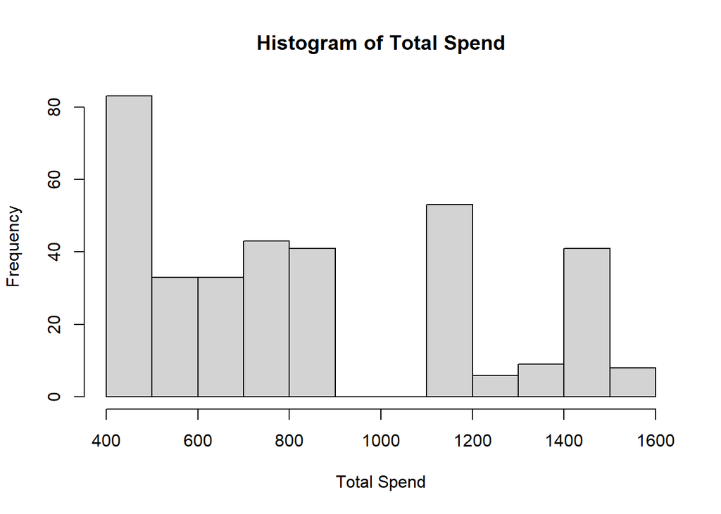

```r
hist(df$total_spend,
     xlab = "Total Spend",
     main = "Histogram of Total Spend")
```

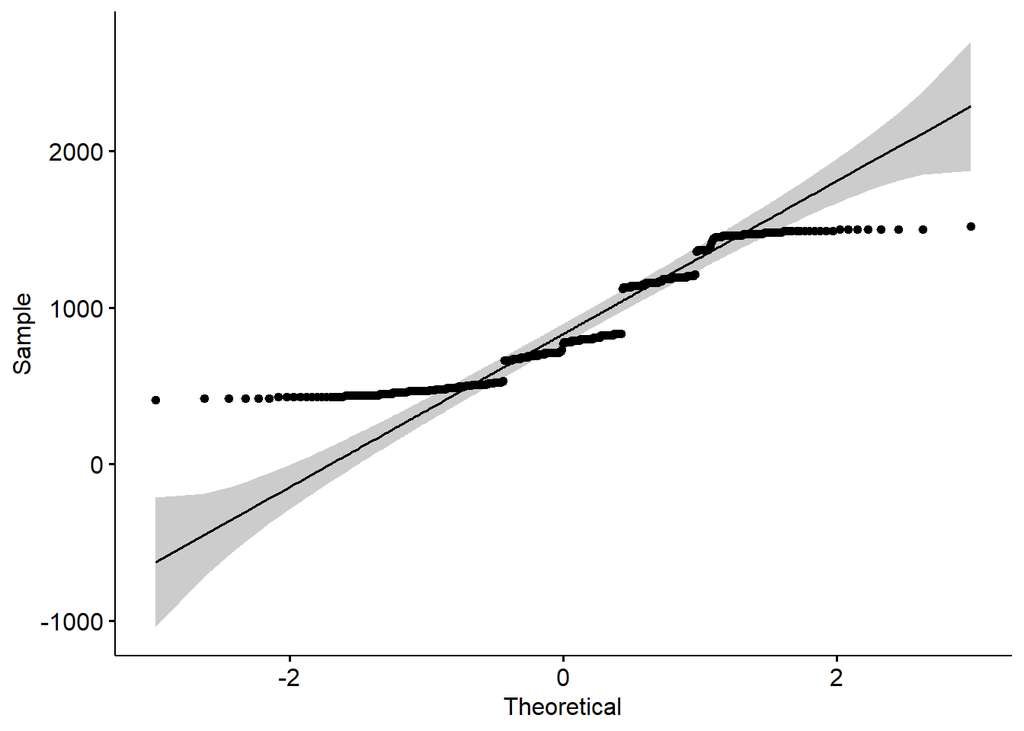

```r
library(ggpubr)
ggqqplot(df$total_spend)
```

## 2.7 Inverse Normal Distribution Transformation

Due to an independent samples t-test requiring the dependent variable to be approximately normally distributed for each group, an inverse normal distribution was done to achieve a roughly normal distribution.

### 2.7.1 Rank the Data

Firstly, the Total_Spend variable was ranked, with the average computed when there is a tie and any missing values be kept.

```r
total_spend_ranking <- rank(df$total_spend,
                            na.last = "keep",
                            ties.method = "average")
```

### 2.7.2 Fractional Ranking and the Inverse Normal Distribution

```r
fractional_rank <- (total_spend_ranking - 0.5) / sum(!is.na(total_spend_ranking))

total_spend_mean <- mean(df$total_spend)

total_spend_std_dev <- sd(df$total_spend)

IDF <- qnorm(fractional_rank,
             total_spend_mean,
             total_spend_std_dev)

df["total_spend_transformed"] <- qnorm(fractional_rank,
                                       total_spend_mean,
                                       total_spend_std_dev)
```

### 2.7.3 Total Spend now Approximately Normally Distributed (Histogram & QQ-Plot)

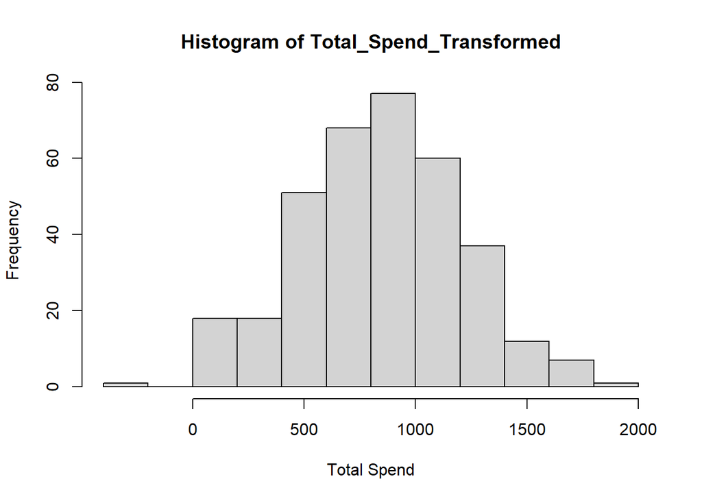

```r
hist(df$total_spend_transformed, xlab = "Total Spend",
     main = "Histogram of Total_Spend_Transformed")
```

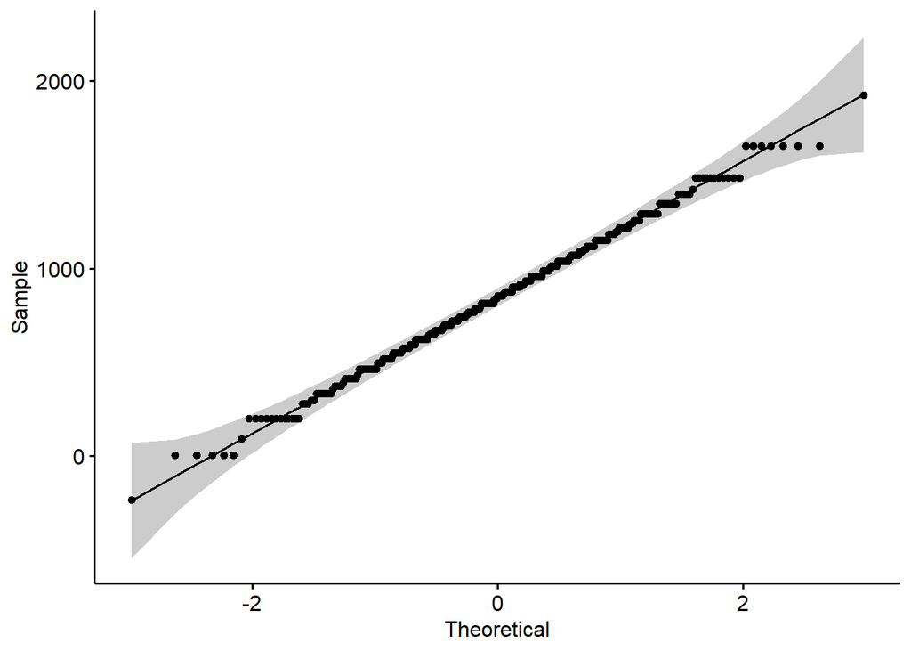

```r
ggqqplot(df$total_spend_transformed)
```

# 3 Descriptive Statistics

The “*Age_Category*” variable was displayed using the *table* function and then converted to a data frame using the *as.data.frame* built-in function. The column names were changed using the *colnames* function. Using the *mutate* function from the *dplyr* library package, a new column “Percentage” was created, and then, the *case_when* function was used to compute the individual percentages for each age category and then rounded off to one decimal The *paged_table* function from the library package *rmarkdown* was used to output the descriptive statistics for age category, while the *plot_frq* function from the *sjplot* library package together with *theme_minimal* and *xlabs* functions from the *ggplot2* library package were used for the visual presentation. The same process was employed when outputing the descriptive statistics for the subsequent variables; *Gender*, *Membership_Type* and *Satisfaction_Level*.

## 3.1 Age Category

About two-third of the consumers were aged 30-39 (63.7%), which constituted the majority, while 19.7% were aged 20-29, and 16.6% were aged 40-49.

```r
age_cat <- as.data.frame(table(df$age_category))

colnames(age_cat) <- c("Age_Category", "Frequency")

age_cat <- age_cat %>%
                      mutate(Percentage = round(case_when(
                      Age_Category == "20-29" ~ 69/350 * 100,
                      Age_Category == "30-39" ~ 223/350 * 100,
                      Age_Category == "40-49" ~ 58/350 * 100
                      ), 1))



rmarkdown::paged_table(age_cat)
```

| Age_Category | Frequency | Percentage |
| --- | --- | --- |
| 20-29 | 69 | 19.7 |
| 30-39 | 223 | 63.7 |
| 40-49 | 58 | 16.6 |

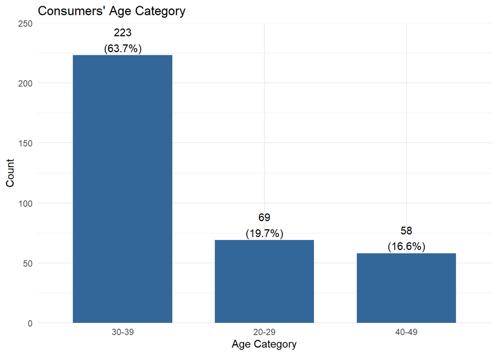

```r
library(sjPlot)
library(ggplot2)

plot_frq(df$age_category,
         sort.frq = "desc",
          show.n = TRUE) +
  theme_minimal() +
  xlab("Age Category") +
  ylab("Count") +
  labs(title = "Consumers' Age Category")
```

## 3.2 Gender

The gender distribution was similar, 50% Male and 50% Female consumers.

```r
gen <- as.data.frame(table(df$gender))

colnames(gen) <- c("Gender",
                   "Frequency")

gen <- gen %>%
              mutate(Percentage = round(case_when(
                Gender == "Female" ~ 175/350 * 100,
                Gender == "Male" ~ 175/350 * 100
                ), 1))


rmarkdown::paged_table(gen)
```

| Gender | Frequency | Percentage |
| --- | --- | --- |
| Female | 175 | 50 |
| Male | 175 | 50 |

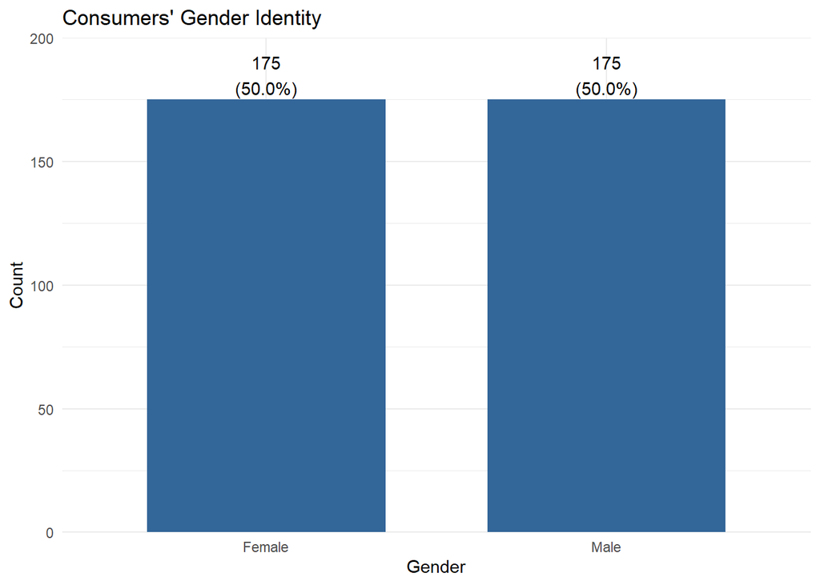

```r
plot_frq(df$gender,
         sort.frq = "desc",
         show.n = TRUE) +
  theme_minimal() +
  labs(title = "Gender") +
  xlab("Gender") +
  ylab("Count") +
  labs(title = "Consumers' Gender Identity")
```

## 3.3 Membership Type

The customers were evenly split among Bronze (33.1%), Silver (33.4%), and Gold (33.4%).

```r
mem_type <- as.data.frame(table(df$membership_type))

colnames(mem_type) <- c("Membership_Type",
                        "Frequency")

mem_type <- mem_type %>%
                        mutate(Percentage = round(case_when(
                        Membership_Type == "Bronze" ~ 116/350 * 100,
                        Membership_Type == "Gold" ~ 117/350 * 100,
                        Membership_Type == "Silver" ~ 117/350 * 100
                      ), 1))



rmarkdown::paged_table(mem_type)
```

| Membership_Type | Frequency | Percentage |
| --- | --- | --- |
| Bronze | 116 | 33.1 |
| Silver | 117 | 33.4 |
| Gold | 117 | 33.4 |

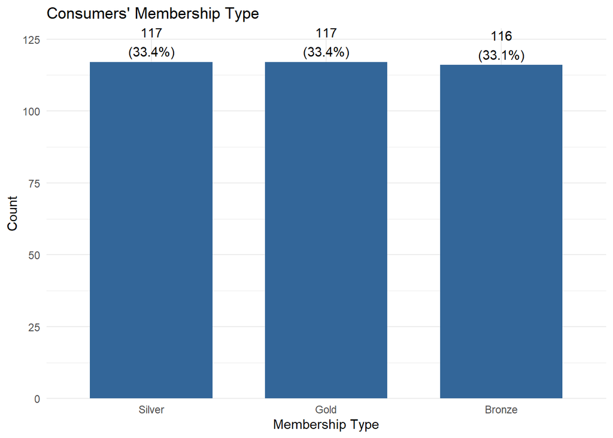

```r
plot_frq(df$membership_type,
         sort.frq = "desc",
         show.n = TRUE) +
  theme_minimal() +
  xlab("Membership Type") +
  ylab("Count") +
  labs(title = "Consumers' Membership Type")
```

## 3.4 Satisfaction Level

```r
sat_lvl <- as.data.frame(table(df$satisfaction_level))

colnames(sat_lvl) <- c("Satisfaction_Level",
                       "Frequency")

sat_lvl <- sat_lvl %>%
                      mutate(Percentage = round(case_when(
                        Satisfaction_Level == "Neutral" ~ 107/350 * 100,
                        Satisfaction_Level == "Satisfied" ~ 127/350 * 100,
                        Satisfaction_Level == "Unsatisfied" ~ 116/350 * 100
                      ), 1))



rmarkdown::paged_table(sat_lvl)
```

| Satisfaction_Level | Frequency | Percentage |
| --- | --- | --- |
| Unsatisfied | 116 | 33.1 |
| Neutral | 107 | 30.6 |
| Satisfied | 127 | 36.3 |

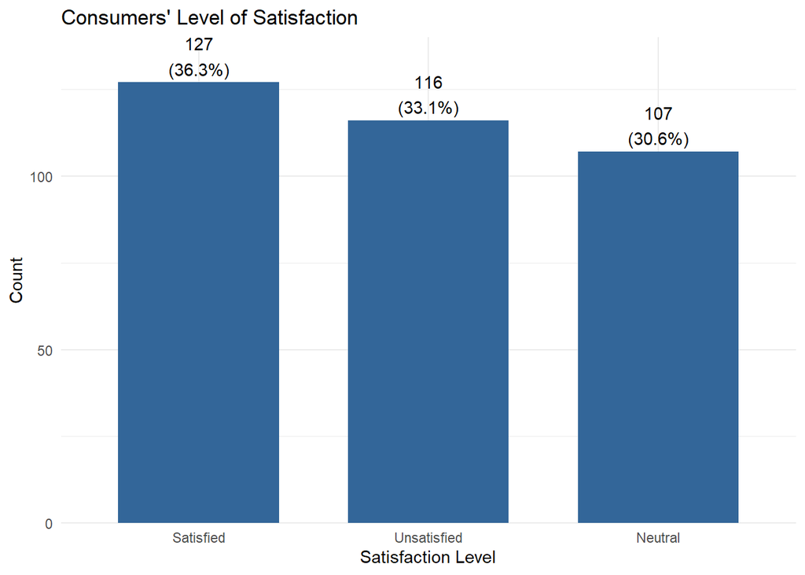

```r
plot_frq(df$satisfaction_level,
         sort.frq = "desc",
         show.n = TRUE,
         show.prc = TRUE) +
  theme_minimal() +
  xlab("Satisfaction Level") +
  ylab("Count") +
  labs(title = "Consumers' Level of Satisfaction")
```

# 4 Customer Segmentation

**Note:** An nstart value of 25 was chosen because the algorithm attempts multiple initial centroid configurations and reports on the best one, so an nstart of 25 will generate 25 initial random centroids and choose the best one for the algorithm.

## 4.1 Determining the Optimal Numbers of Clusters to Use

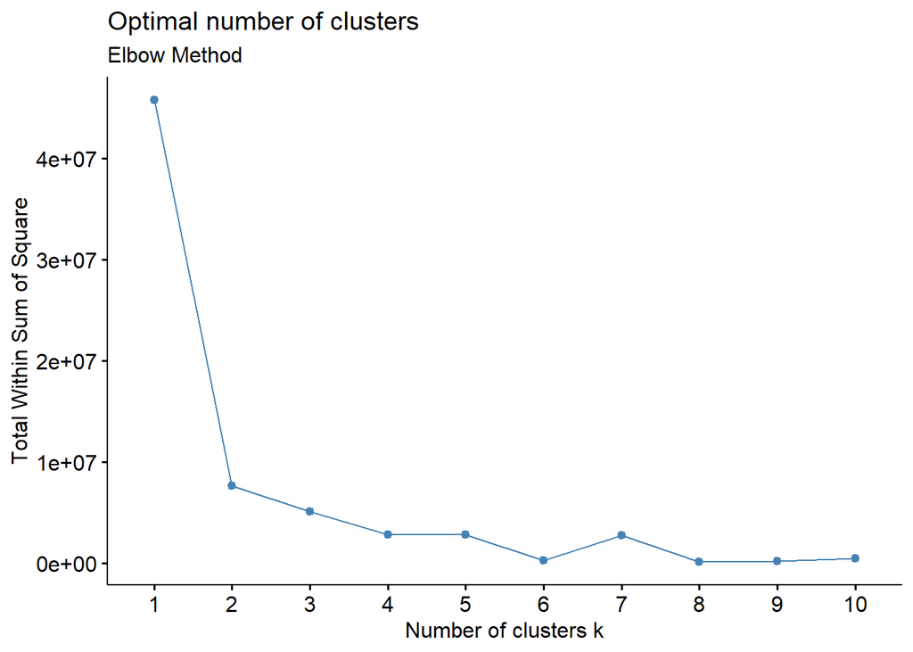

```r
k_means_df <- select(df,
                     age,
                     total_spend,
                     items_purchased)


library(factoextra)
fviz_nbclust(x = k_means_df,
             FUNcluster = kmeans,
             method = "wss") +
  labs(subtitle = "Elbow Method")
```

## 4.2 Clustering Result

From the results generated, we can observe that cluster 1 comprises slightly older, moderate-spenders, cluster 2 was made up of Younger, higher-spenders, while cluster 3 consists of Older-low-spenders.

Cluster 1 (*n* = 117) features slightly older customers (*M* = 32) who purchase a moderate number of items (*M* = 12). Cluster 2 (*n* = 117) comprises younger customers (*M* = 30) with the highest number of items purchased (*M* = 18). Cluster 3 (*n* = 116) consists of older customers (*M* = 39) with the fewest items purchased (*M* = 9).

The total amount of money spent varied significantly across the three clusters: younger customers tend to spend more ($1311.14), slightly older customers spend a moderate amount ($748.43), while older customers tend to spend less ($473.39) and purchase fewer items. Since younger customers tend to spend more and buy more, the company should appropriately target this cluster with promotions. For older customers, marketing research should be carried out to identify ways to encourage them to spend and buy more.

```r
K_Means_Clustering <- kmeans(k_means_df,
                             centers = 3,
                             iter.max = 50,
                             nstart = 25)
print(K_Means_Clustering)
```

```
K-means clustering with 3 clusters of sizes 117, 117, 116

Cluster means:
       age total_spend items_purchased
1 31.55556    748.4325       11.658120
2 29.92308   1311.1444       17.615385
3 39.36207    473.3888        8.491379

Clustering vector:
  [1] 2 1 3 2 1 3 2 1 3 2 1 3 2 1 3 2 1 3 2 1 3 2 1 3 2 1 3 2 1 3 2 1 3 2 1 3 2
 [38] 1 3 2 1 3 2 1 3 2 1 3 2 1 3 2 1 3 2 1 3 2 1 3 2 1 3 2 1 3 2 1 3 2 1 3 2 1
 [75] 3 2 1 3 2 1 3 2 1 3 2 1 3 2 1 3 2 1 3 2 1 3 2 1 3 2 1 3 2 1 3 2 1 3 2 1 3
[112] 2 1 3 2 1 3 2 1 3 2 1 3 2 1 3 2 1 3 2 1 3 2 1 3 2 1 3 2 1 3 2 1 3 2 1 3 2
[149] 1 3 2 1 3 2 1 3 2 1 3 2 1 3 2 1 3 2 1 3 2 1 3 2 1 3 2 1 3 2 1 3 2 1 3 2 1
[186] 3 2 1 3 2 1 3 2 1 3 2 1 3 2 1 2 1 3 2 1 3 2 1 3 2 1 3 2 1 3 2 1 3 2 1 3 2
[223] 1 3 2 1 3 2 1 3 2 1 3 2 1 3 2 1 3 2 1 3 2 1 3 2 1 3 2 1 3 2 1 3 2 1 3 2 1
[260] 3 2 1 3 2 1 3 2 1 3 2 1 3 2 1 3 2 1 3 2 1 3 2 1 3 2 1 3 2 1 3 2 1 3 2 1 3
[297] 2 1 3 2 1 3 2 1 3 2 1 3 2 1 3 2 1 3 2 1 3 2 1 3 2 1 3 2 1 3 2 1 3 2 1 3 2
[334] 1 3 2 1 3 2 1 3 2 1 3 2 1 3 2 1 3

Within cluster sum of squares by cluster:
[1]  427312.1 2678551.0  113686.1
 (between_SS / total_SS =  93.0 %)

Available components:

[1] "cluster"      "centers"      "totss"        "withinss"     "tot.withinss"
[6] "betweenss"    "size"         "iter"         "ifault"
```

## 4.3 Visualization of the K-Means Clusters

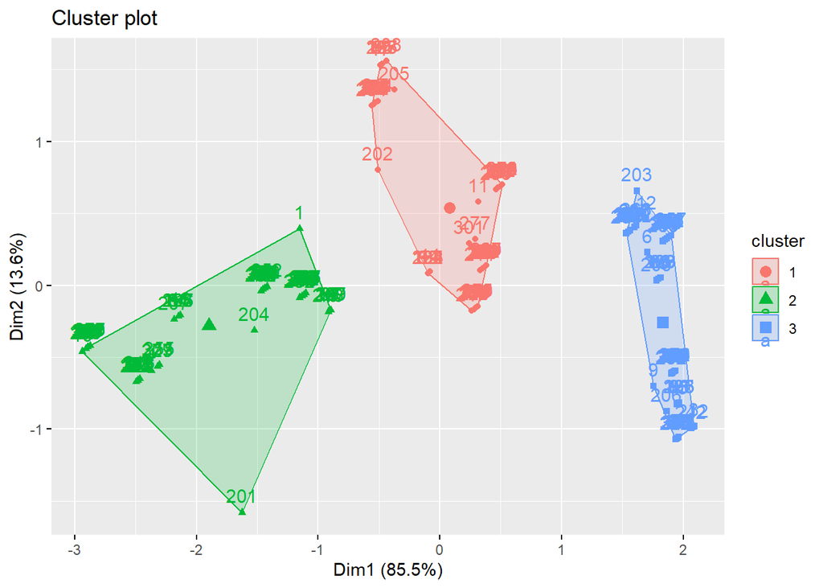

```r
fviz_cluster(K_Means_Clustering,
             data = k_means_df)
```

## 4.4 Saving and classifying the clusters

```r
df["cluster_membership"] <- K_Means_Clustering$cluster

df <- df %>%
            mutate(cluster_membership = case_when(
            cluster_membership == 1 ~ "Slightly older, moderate-spenders",
            cluster_membership == 2 ~ "Younger high-spenders",
            cluster_membership == 3 ~ "Older low-spenders"
            ))
```

# 5 Relationship Between Gender and Membership Type

Using the *sjPlot* library package, the function *tab_xtab* was used to conduct and present the result from a chi-square test of independence between gender and membership type, while the *plot_xtab* function was used for the visual presentation. Other functions such as *theme_minimal*, *xlabs* and *scale_fill_manual* from the *ggplot2* library package was used.

For the post-hoc test, the built-in function *chisq.test* along with *$stdres* was used to print only the standardised residuals. The output was then converted to a data frame, using the *as.data.frame* function, the standardised residuals were rounded off to one decimal, finally the column names were changed using the *colnames* function.

The Pearson’s Chi-squared test of independence between Gender and Membership Type suggests that the effect is statistically significant, and very large (χ² = 229.04, *p* < .001; Adjusted Cramer’s v = 0.81, 95% CI [0.72, 1.00]).

**Note:** the values in the crosstab were changed from the default black colour to white for visibility purpose due to the darkly theme used for the html output.

```r
tab_xtab(
  var.row = df$gender,
  var.col = df$membership_type,
  show.row.prc = TRUE,
  show.exp = TRUE,
  tdcol.n = "white",
  tdcol.row = "white",
  tdcol.expected = "white",
  title = "Crosstabulation between Gender and Membership Type"
)
```

Crosstabulation between Gender and Membership Type

| gender | membership_type |  |  | Total |  |
| --- | --- | --- | --- | --- | --- |
|  | Bronze | Silver | Gold |  |  |
| Female | 116 58 66.3 % | 1 58 0.6 % | 58 58 33.1 % |  | 175 175 100 % |
| Male | 0 58 0 % | 116 58 66.3 % | 59 58 33.7 % | 175 175 100 % |  |
| Total | 116 116 33.1 % | 117 117 33.4 % | 117 117 33.4 % | 350 350 100 % |  |

## 5.1 Post-hoc Test

Examination of standardised residuals indicated that males were highly over represented in the silver membership category (adjusted residual = 13.0) and completely absent from the bronze category (adjusted residual = -13.2). Conversely, females were significantly over represented in the bronze category (adjusted residual = 13.2) and almost absent from the silver category (adjusted residual = -13.0). No significant deviation was observed in the gold membership category (adjusted residual = 0.1 for males, -0.1 for females), indicating a roughly equal distribution of gold membership across genders.

```r
std_residuals_gen_mem <- as.data.frame(round(chisq.test(df$gender,
                                                df$membership_type)$stdres, 1))

  colnames(std_residuals_gen_mem) <- c("Gender",
                                       "Membership Type",
                                       "Standardised Residuals")

  rmarkdown::paged_table(std_residuals_gen_mem)
```

| Gender | Membership Type | Standardised Residuals |
| --- | --- | --- |
| Female | Bronze | 13.2 |
| Male | Bronze | -13.2 |
| Female | Silver | -13.0 |
| Male | Silver | 13.0 |
| Female | Gold | -0.1 |
| Male | Gold | 0.1 |

## 5.2 Visualisation

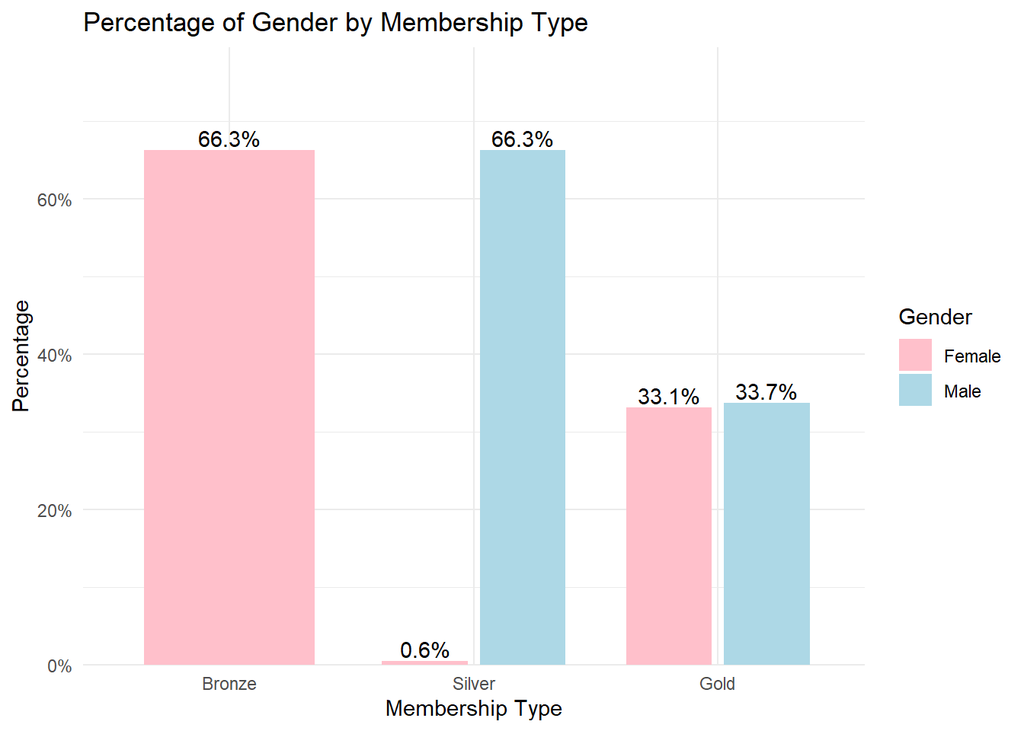

```r
gender_member_viz <- plot_xtab(
  x = df$membership_type,
  grp = df$gender,
  margin = "col",
  bar.pos = "dodge",
  show.summary = FALSE,
  coord.flip = FALSE,
  show.total = FALSE,
  show.prc = TRUE,
  show.n = FALSE,
  title = "Percentage of Gender by Membership Type",
  legend.title = "Gender"
) +
  theme_minimal() +
  xlab("Membership Type") +
  ylab("Percentage") +
  scale_fill_manual(values = c("Female" = "pink",
                               "Male" = "lightblue"))

gender_member_viz$data = gender_member_viz$data[gender_member_viz$data$prc!= 0,]

print(gender_member_viz)
```

# 6 Relationship Between Age Demographics and Spending

The group statistics for the one-way anova was obtained by calculating the mean, standard deviation and variance of the variable total spend for each age category, which was then rounded off to two decimals. The *levene_test* function from the *rstatix* library package was used to confirm whether the variances were equal. At a glace, we can observe that the variances are unequal, which was also confirmed by the Levene’s test based on median, and since the group sizes are also unequal (Grace-Martin 2023), a Welch ANOVA was conducted.

The *age_category* was converted to a factor variable using the **as.factor** built-in function.

## 6.1 Group Statistics

```r
anova_descriptive <- df %>%
                          group_by(age_category) %>%
                          summarise(n = n(),
                          Mean = round(mean(total_spend), 2),
                          Standard_Deviation = round(sd(total_spend), 2),
                          Variance = round(sqrt(Standard_Deviation), 2))



rmarkdown::paged_table(anova_descriptive)
```

| age_category | n | Mean | Standard_Deviation | Variance |
| --- | --- | --- | --- | --- |
| 20-29 | 69 | 1072.18 | 378.66 | 19.46 |
| 30-39 | 223 | 865.07 | 338.43 | 18.40 |
| 40-49 | 58 | 499.88 | 15.28 | 3.91 |

```r
df$age_category <- as.factor(df$age_category)
```

## 6.2 Levene’s Test for Equal Variances (Median)

*Note:* The Levene’s test for equal variances is sensitive to large sample size, which would lead to higher statistical power, thus high risk of committing a type 1 error (incorrectly rejecting the null hypothesis), expect in this case where the test correctly concluded that the variances are not roughly equal, which can be seen from the “Group Statistics” table as group 3 has a significantly lower variance compared to group 1 and 2.(Grace-Martin 2025)

The median was used over the mean for Levene’s test, due to the dependent variable not being normally distributed. Centering around the median makes the test more robust, providing the correct statistical level even for not normal distributions (Carroll and Schneider 1985)

```r
library(rstatix)

equal_var_test <- levene_test(data = df, total_spend ~ age_category,
                              center = "median")


equal_var_test <- equal_var_test %>%
                                    mutate(statistic = round(statistic, 2),
                                          p = case_when(
                                            p <0.001 ~ "<0.001"
                                            ))

rmarkdown::paged_table(equal_var_test)
```

| df1 | df2 | statistic | p |
| --- | --- | --- | --- |
| 2 | 347 | 49.74 | <0.001 |

## 6.3 Welch ANOVA Model

A Welch ANOVA was conducted to determine whether there were significant differences in total spending based on age category. There was a statistically significant difference in total spending among the three age groups *F*(2,139) = 205.71, *p* < .001. The effect size Epsilon Squared was 0.23 (23%), indicating that the independent variable age category explained 23% of the variation in the dependent variable total spent. This was obtained using the “*effectsize*” library package with the function “*epsilon_squared*”.

**Note:** The function *welch_anova_test* from the *rstatix* library package, was used conduct the Welch anova. The values from the result were rounded off to two decimals, including the effect size with its confidence intervals, while the p-value was converted form a scientific notation to a more readable format. The post-hoc estimates, its confidence interval were rounded off to two decimals, while the adjusted p-value was converted from a scientific notation into a more readable format.

```r
library(rstatix)

welch_anova <- df %>%
                      welch_anova_test(total_spend ~ age_category) %>%
                      mutate( p = case_when(
                              p <0.001 ~ "<0.001"
                              )) %>%
                      mutate(across(c(3:5), round, 2))





rmarkdown::paged_table((welch_anova))
```

| .y. | n | statistic | DFn | DFd | p | method |
| --- | --- | --- | --- | --- | --- | --- |
| total_spend | 350 | 205.71 | 2 | 139.72 | <0.001 | Welch ANOVA |

## 6.4 ANOVA Effect Size

```r
library(effectsize)

anova_effect <- epsilon_squared(aov(total_spend ~ age_category,
                                    data = df)) %>%
                                mutate(across(c(2:4), round, 2))


rmarkdown::paged_table(anova_effect)
```

| Parameter | Epsilon2 | CI | CI_low | CI_high |
| --- | --- | --- | --- | --- |
| age_category | 0.23 | 0.95 | 0.16 | 1 |

## 6.5 Post-hoc Test (Games-Howell Test)

Post-hoc analysis using the Games-Howell test revealed that customers aged 20-29 spent significantly more ($1072.18 ) than those aged 30-39 ($865.07), with a mean difference of $207.12, *p* < .001. Similarly, those age 20-29 spent significantly more than those aged 40-49 ($499.88), with a mean difference of $572.30 Significant differences were also between the 30–39 and 40–49 age groups with a mean difference of $365.18, *p* < .001

```r
post_hoc <- df %>%
                  games_howell_test(total_spend ~ age_category) %>%
                        mutate(p.adj = case_when(
                        p.adj <0.001 ~ "<0.001"
                        )) %>%
                        mutate(across(c(4:6), round, 2))



rmarkdown::paged_table(post_hoc)
```

| .y. | group1 | group2 | estimate | conf.low | conf.high | p.adj | p.adj.signif |
| --- | --- | --- | --- | --- | --- | --- | --- |
| total_spend | 20-29 | 30-39 | -207.12 | -328.17 | -86.07 | <0.001 | *** |
| total_spend | 20-29 | 40-49 | -572.30 | -681.62 | -462.98 | <0.001 | **** |
| total_spend | 30-39 | 40-49 | -365.18 | -418.86 | -311.51 | <0.001 | **** |

## 6.6 Visual Representation of the ANOVA Result

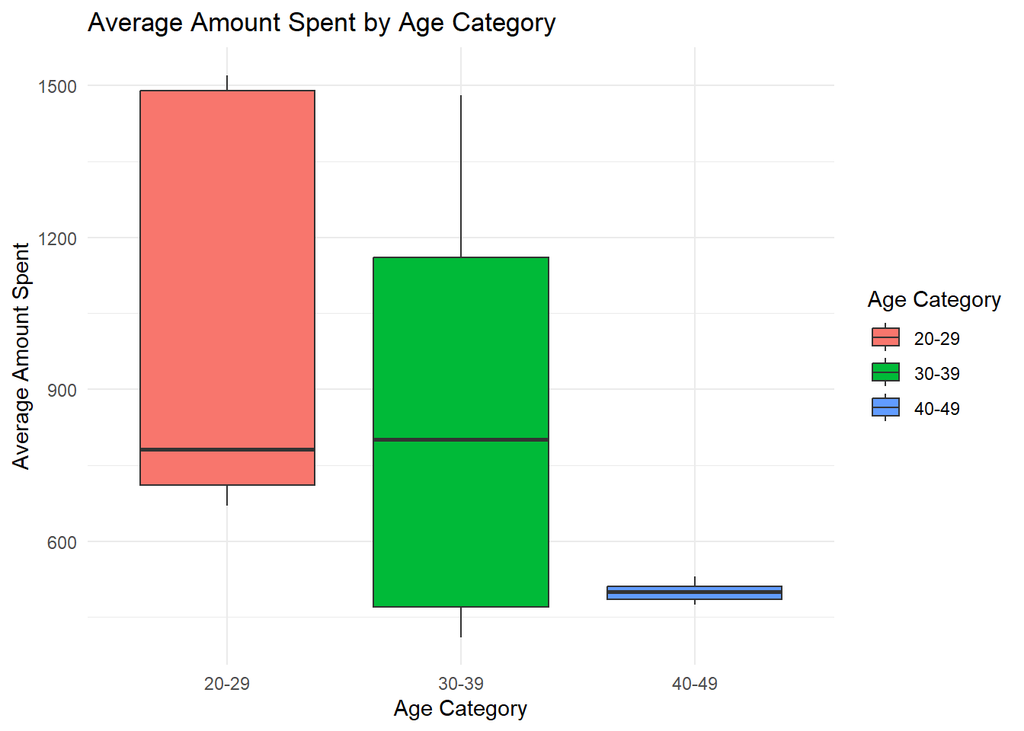

```r
ggplot(df, aes(age_category,total_spend, fill = age_category)) +
  geom_boxplot() +
  theme_minimal() +
  labs(title = "Average Amount Spent by Age Category",
       fill = "Age Category") +
  xlab("Age Category") +
  ylab("Average Amount Spent")
```

# 7 Customer Satisfaction Analysis

Using the *sjPlot* library package, the function *tab_xtab* was used to conduct and present the result from a chi-square test of independence between membership type and satisfaction level, while the *plot_xtab* function was used for the visual presentation. Other functions such as *theme_minimal*, *xlabs* and *scale_fill_manual* from the *ggplot2* library package was used.

For the post-hoc test, the built-in function *chisq.test* along with *$stdres* was used to print only the standardised residuals. The output was then converted to a data frame, using the *as.data.frame* function, the standardised residuals were rounded off to one decimal, finally the column names were changed using the *colnames* function.

The Pearson’s Chi-squared test of independence between Membership_Type and Satisfaction_Level suggests that the effect is statistically significant, and very large (χ² = 309.44, *p* < .001; Adjusted Cramer’s v = 0.66, 95% CI [0.60,1.00]).

**Note:** the values in the crosstab were changed from the default black colour to white for visibility purpose due to the darkly theme used for the html output.

```r
tab_xtab(
  var.row = df$membership_type,
  var.col = df$satisfaction_level,
  show.exp = TRUE,
  show.row.prc = TRUE,
  tdcol.n = "white",
  tdcol.expected = "white",
  tdcol.row = "white",
  title = "Crosstabulation between Membership Type and Level of Satisfaction"
)
```

Crosstabulation between Membership Type and Level of Satisfaction

| membership_type | satisfaction_level |  |  | Total |  |
| --- | --- | --- | --- | --- | --- |
|  | Unsatisfied | Neutral | Satisfied |  |  |
| Bronze | 58 38 50 % | 56 35 48.3 % | 2 42 1.7 % |  | 116 116 100 % |
| Silver | 58 39 49.6 % | 51 36 43.6 % | 8 42 6.8 % | 117 117 100 % |  |
| Gold | 0 39 0 % | 0 36 0 % | 117 42 100 % | 117 117 100 % |  |
| Total | 116 116 33.1 % | 107 107 30.6 % | 127 127 36.3 % | 350 350 100 % |  |

## 7.1 Post-hoc Test

```r
library(rmarkdown)
std_residuals_mem_sat <- as.data.frame(round(chisq.test(df$membership_type,
                                   df$satisfaction_level)$stdres, 1))


  colnames(std_residuals_mem_sat) <- c("Membership Type",
                                        "Satisfaction Level",
                                        "Standardised Residuals")

  rmarkdown::paged_table(std_residuals_mem_sat)
```

| Membership Type | Satisfaction Level | Standardised Residuals |
| --- | --- | --- |
| Bronze | Unsatisfied | 4.7 |
| Silver | Unsatisfied | 4.6 |
| Gold | Unsatisfied | -9.3 |
| Bronze | Neutral | 5.1 |
| Silver | Neutral | 3.7 |
| Gold | Neutral | -8.8 |
| Bronze | Satisfied | -9.5 |
| Silver | Satisfied | -8.1 |
| Gold | Satisfied | 17.6 |

## 7.2 Visualisation

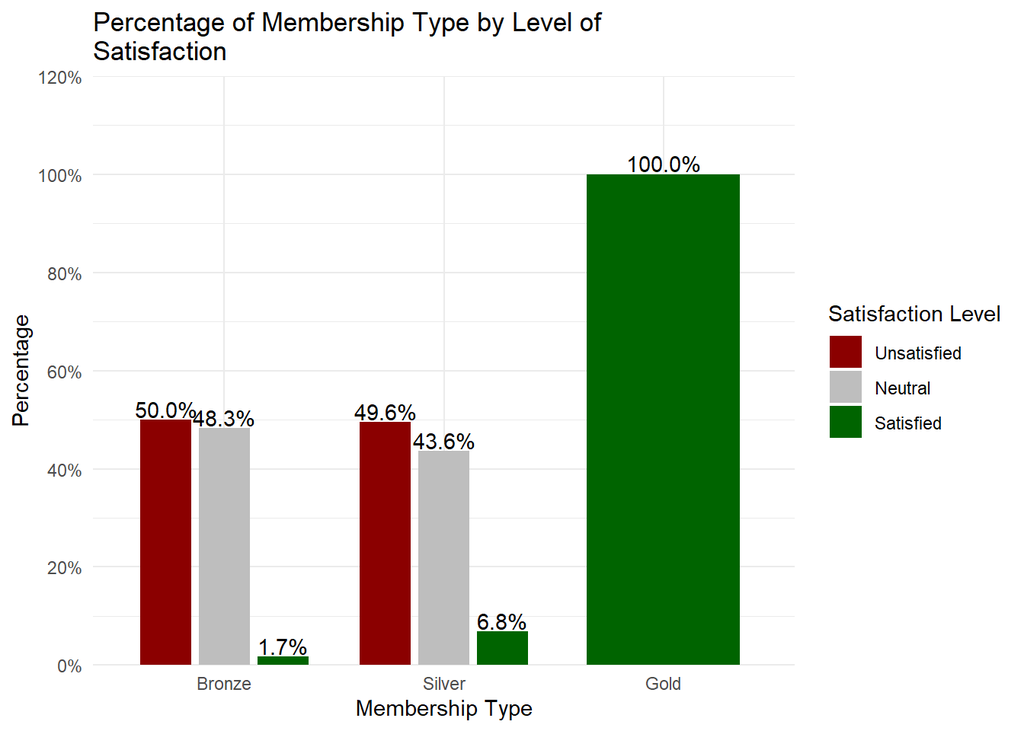

```r
member_satisfaction_viz <- plot_xtab(
                                      x = df$membership_type,
                                      grp = df$satisfaction_level,
                                      margin = "row",
                                      bar.pos = "dodge",
                                      coord.flip = FALSE,
                                      show.total = FALSE,
                                      show.n = FALSE,
                                      show.prc = TRUE,
                                      title = "Percentage of Membership Type by Level of Satisfaction",
                                      legend.title = "Satisfaction Level"
) +
  theme_minimal() +
  xlab("Membership Type") +
  ylab("Percentage") +
  scale_fill_manual(values = c("Neutral" = "grey",
                               "Satisfied" = "darkgreen",
                               "Unsatisfied" = "darkred"))

member_satisfaction_viz$data = member_satisfaction_viz$data[member_satisfaction_viz$data$prc != 0 ,]

print(member_satisfaction_viz)
```

# 8 Effect of Discounts on Purchase Behaviour

## 8.1 Group Statistics

```r
t_test_descriptive <- df %>%
                            group_by(discount_applied) %>%
                            summarise(n = n(),
                                      Mean = round(mean(total_spend_transformed), 2),
                                      Standard_Deviation =
                                        round(sd(total_spend_transformed), 2),
                                      Variance = round(sqrt(Standard_Deviation), 2))


rmarkdown::paged_table(t_test_descriptive)
```

| discount_applied | n | Mean | Standard_Deviation | Variance |
| --- | --- | --- | --- | --- |
| FALSE | 175 | 870.74 | 461.18 | 21.48 |
| TRUE | 175 | 819.84 | 213.59 | 14.61 |

## 8.2 Levene’s Test for Equal Variances (Mean)

```r
library(rstatix)

equal_var_test_t_test <- levene_test(data = df,
                                     total_spend ~ discount_applied,
                                     center = "mean")


equal_var_test_t_test <- equal_var_test_t_test %>%
                                    mutate(statistic = round(statistic, 2),
                                          p = case_when(
                                            p <0.001 ~ "<0.001"
                                            ))

rmarkdown::paged_table(equal_var_test_t_test)
```

| df1 | df2 | statistic | p |
| --- | --- | --- | --- |
| 1 | 348 | 42.03 | <0.001 |

## 8.3 T-Test Model

A two-tailed independent samples t-test was conducted using the “*rstatix*” library package to compare the total spending between customers who had a discount applied and those who did not. There was no significant difference in total spending for customers with a discount (*M* = 819.84 , *SD* = 213.59) and without a discount (*M* = 870.74, *SD* = 461.18 ), *t*(348) = 1.32, *p* = 0.19 The effect size, as measured by Cohen’s d, was d = 0.14, indicating a small effect size.

```r
library(rstatix)
t_test_model <- t_test(data = df,
                       total_spend_transformed ~ discount_applied,
                       var.equal = TRUE,
                       detailed = TRUE,
                       conf.level = 0.95) %>%
                mutate_if(is.numeric, ~round(.,2))


rmarkdown::paged_table(t_test_model)
```

| estimate | estimate1 | estimate2 | .y. | group1 | group2 | n1 | n2 | statistic | p | df | conf.low | conf.high | method | alternative |
| --- | --- | --- | --- | --- | --- | --- | --- | --- | --- | --- | --- | --- | --- | --- |
| 50.9 | 870.74 | 819.84 | total_spend_transformed | FALSE | TRUE | 175 | 175 | 1.32 | 0.19 | 348 | -24.66 | 126.46 | T-test | two.sided |

```r
t_test_effect <- cohens_d(data = df,
                          total_spend_transformed ~ discount_applied,
                          var.equal = TRUE) %>%
                mutate_if(is.numeric, ~round(.,2))



rmarkdown::paged_table(t_test_effect)
```

| Cohens_d | CI | CI_low | CI_high |
| --- | --- | --- | --- |
| 0.14 | 0.95 | -0.07 | 0.35 |

## 8.4 Visualisation

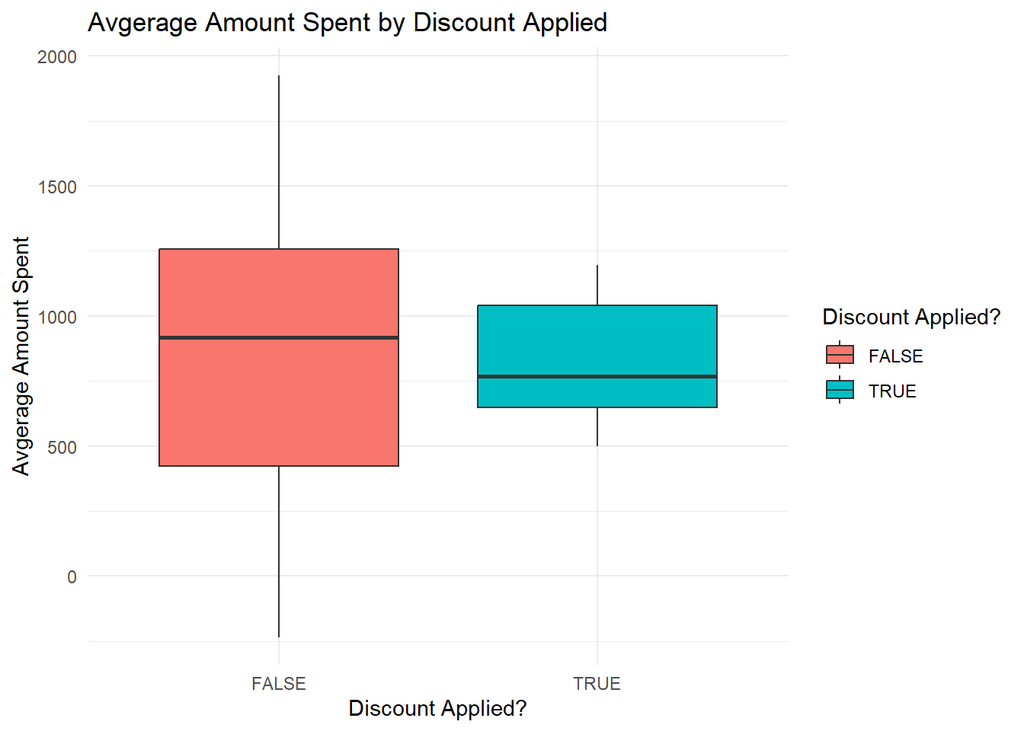

```r
df$discount_applied <- as.factor(df$discount_applied)

ggplot(df, aes(discount_applied, total_spend_transformed,
               fill = discount_applied)) +
  geom_boxplot() +
  theme_minimal() +
  labs(title = "Avgerage Amount Spent by Discount Applied",
       fill = "Discount Applied?") +
  xlab("Discount Applied?") +
  ylab("Avgerage Amount Spent")
```

# References

Carroll, Raymond J, and Helmut Schneider. 1985. “A Note on Levene’s Tests for Equality of Variances.” *Statistics & Probability Letters* 3 (4): 191–94. https://doi.org/10.1016/0167-7152(85)90016-1.

Grace-Martin, Karen. 2023. “When Unequal Sample Sizes Are and Are NOT a Problem in ANOVA.” *The Analysis Factor*. https://www.theanalysisfactor.com/when-unequal-sample-sizes-are-and-are-not-a-problem-in-anova/.

———. 2025. “The Problem with Using Tests for Statistical Assumptions.” *The Analysis Factor*. https://www.theanalysisfactor.com/the-problem-with-tests-for-statistical-assumptions/.